# Geography 176A

#Question 4

**Dam purposes: Irrigation, Hydroelectric, Flood Control, Water Supply, and Fish and Wildlife**

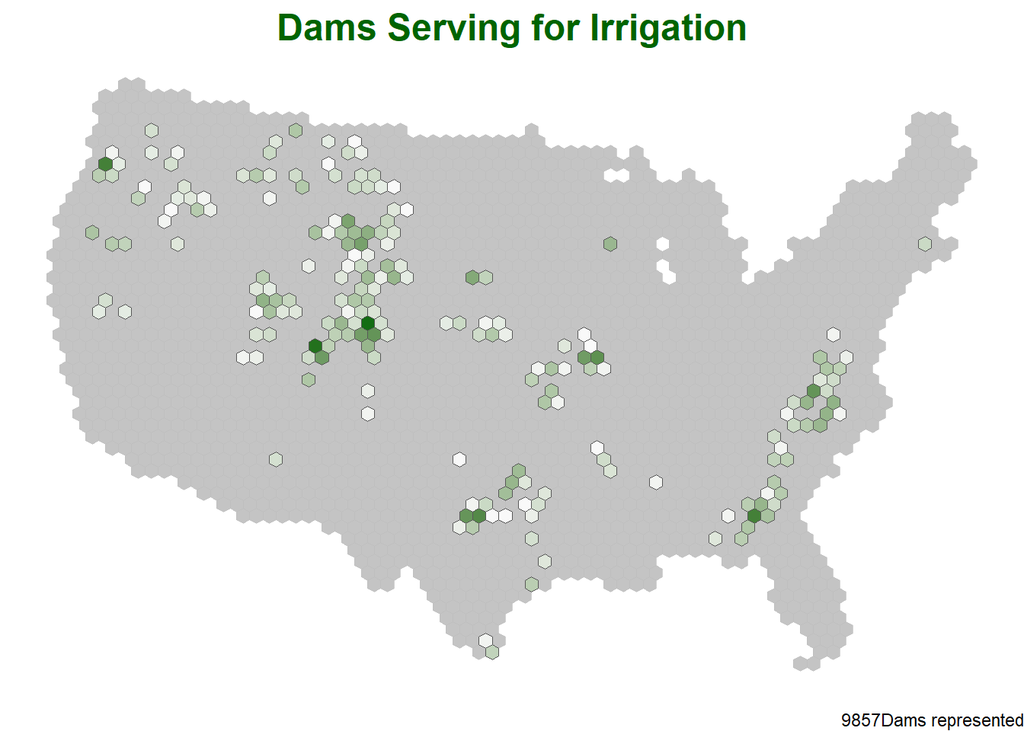

```r
I_NID2019_U <- sf_NID2019_U %>%
  filter(grepl("I", sf_NID2019_U$PURPOSES) == TRUE)
point_in_polygon3(I_NID2019_U, hex_grid, "id") %>%
  plot_pip("Dams Serving for Irrigation") +
  gghighlight(n > (mean(n) + sd(n)))
```

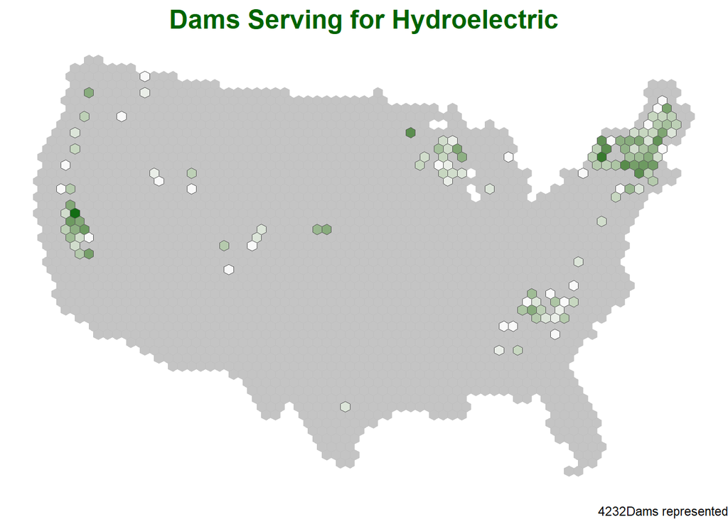

```r
H_NID2019_U <- sf_NID2019_U %>%
  filter(grepl("H", sf_NID2019_U$PURPOSES) == TRUE)
point_in_polygon3(H_NID2019_U, hex_grid, "id") %>%
  plot_pip("Dams Serving for Hydroelectric") +
  gghighlight(n > (mean(n) + sd(n)))
```

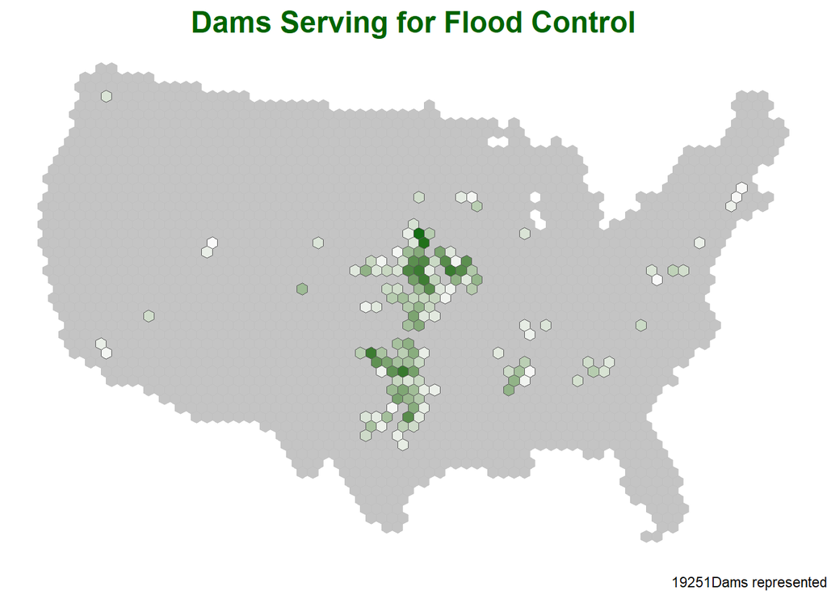

```r
C_NID2019_U <- sf_NID2019_U %>%
  filter(grepl("C", sf_NID2019_U$PURPOSES) == TRUE)
point_in_polygon3(C_NID2019_U, hex_grid, "id") %>%
  plot_pip("Dams Serving for Flood Control") +
  gghighlight(n > (mean(n) + sd(n)))
```

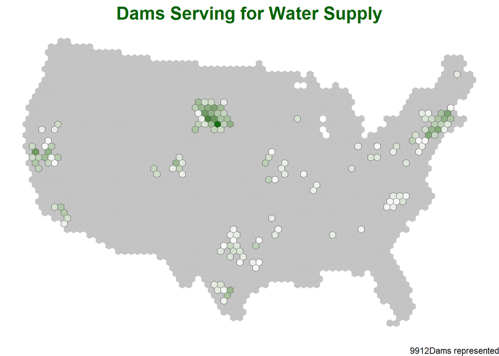

```r
S_NID2019_U <- sf_NID2019_U %>%
  filter(grepl("S", sf_NID2019_U$PURPOSES) == TRUE)
point_in_polygon3(S_NID2019_U, hex_grid, "id") %>%
  plot_pip("Dams Serving for Water Supply") +
  gghighlight(n > (mean(n) + sd(n)))
```

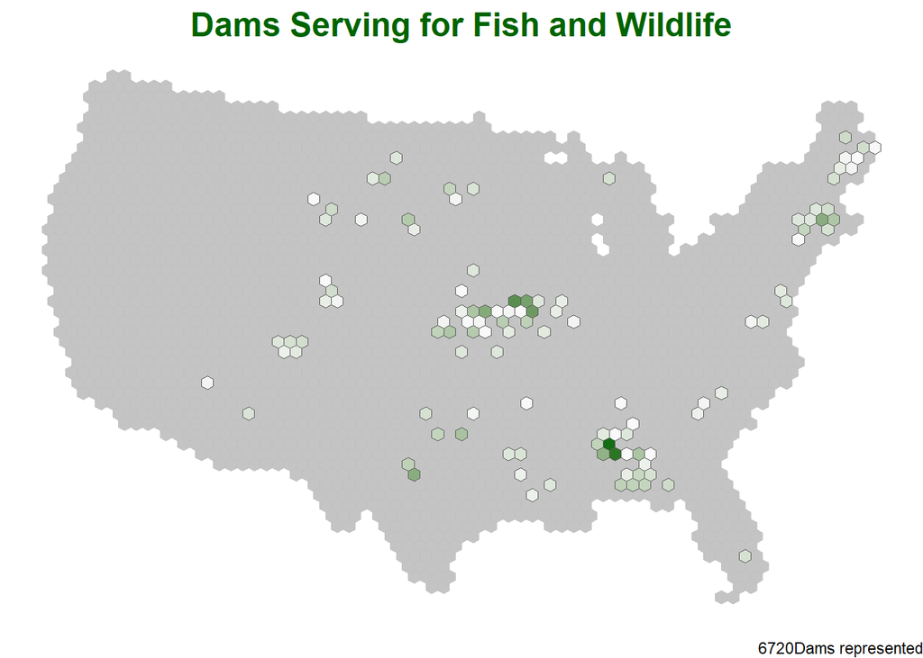

```r
F_NID2019_U <- sf_NID2019_U %>%
  filter(grepl("F", sf_NID2019_U$PURPOSES) == TRUE)
point_in_polygon3(F_NID2019_U, hex_grid, "id") %>%
  plot_pip("Dams Serving for Fish and Wildlife") +
  gghighlight(n > (mean(n) + sd(n)))
```

* Dams serving for irrigation: Center in the northwest and southeast of the United States. The northwest part concentrated at the east of the Rockies lies on the leeward sides of the prevailing westerly winds. Moisture from the Pacific is almost impossible to come by, making it one of the driest parts of the United States, so dams for irrigation are concentrated in this area. The southeast part, near the Gulf Coast, suffers from seasonal drought due to the warm Gulf Stream, so dams used for irrigation are concentrated in this region. * Dams serve for hydroelectric: Center in the western and northeastern coastal areas of the United States. These areas are close to the sea, which is good for generating electricity. * Dams serving for flood control: Center in the central United States. Located in the temperate monsoon climate where rainfall is high and where floods often occur. * Dams serving for water supply: Around large cities, where water demands are high. * Dams serving for fish and wildlife: Close to the inland National Wildlife Refuge where the demand of dams serving for fish and wildlife is high.

#Extra Credit

```r
NID2019_U <- read_excel("~/github/geog-176A-labs/data/NID2019_U.xlsx")

mississippi <- read_sf("~/github/geog-176A-labs/data/MajorRivers") %>%
  filter(SYSTEM == "Mississippi")
```

```r
largest_storage = NID2019_U %>%
  filter(HAZARD == "H") %>%
  filter(!STATE %in% c("AK", "PR", "HI")) %>%
  filter(PURPOSES == "C") %>%
  group_by(STATE) %>%
  slice_max(NID_STORAGE, n=1)

labels <- largest_storage %>%
  select(DAM_NAME, NID_STORAGE, PURPOSES, YEAR_COMPLETED)

leaflet() %>%
  addProviderTiles(providers$CartoDB) %>%
  addCircleMarkers(data = largest_storage,
                   color = "red",
                   fillOpacity = 0.5,
                   stroke = FALSE,
                   popup = leafpop::popupTable(labels, feature.id = FALSE, row.numbers = FALSE),
                   radius = largest_storage$NID_STORAGE/1500000,
  ) %>%
  addPolylines(data = mississippi)
```

[interactive chart not shown]